# Hayman Fire Recovery

Derek Fedak

Monday 07 February, 2022

```r
library(tidyverse)
library(tidyr)
library(ggthemes)
library(gridExtra)
library(lubridate)

# Now that we have learned how to munge (manipulate) data
# and plot it, we will work on using these skills in new ways

knitr::opts_knit$set(root.dir='..')
```

```r
####-----Reading in Data and Stacking it ----- ####
#Reading in files
files <- list.files('data',full.names=T)


#Read in individual data files
ndmi <- read_csv(files[1]) %>%
  rename(burned=2,unburned=3) %>%
  mutate(data='ndmi')


ndsi <- read_csv(files[2]) %>%
  rename(burned=2,unburned=3) %>%
  mutate(data='ndsi')

ndvi <- read_csv(files[3])%>%
  rename(burned=2,unburned=3) %>%
  mutate(data='ndvi')

# Stack as a tidy dataset
full_long <- rbind(ndvi,ndmi,ndsi) %>%
  gather(key='site',value='value',-DateTime,-data) %>%
  filter(!is.na(value))
#With pivot_longer
full_long_a <- rbind(ndvi, ndmi, ndsi) %>%
  pivot_longer(-c(DateTime, data), names_to = 'site', values_to = 'value', values_drop_na = TRUE)

# Example stack as a tidy dataset
full_long2 <- rbind(ndvi, ndmi, ndsi) %>%
  gather(key='treatment', value='veg_index', -DateTime, -data) %>%
  filter(!is.na('veg_index'))
#With pivot_longer
full_long2_a <- rbind(ndvi, ndmi, ndsi) %>%
  pivot_longer(-c(DateTime, data), names_to = 'treatment', values_to = 'veg_index', values_drop_na = TRUE)
```

## Question 1)

What is the correlation between NDVI and NDMI? - here I want you to convert the full_long dataset in to a wide dataset using the function “spread” and then make a plot that shows the correlation s a function of if the site was burned or not (x axis should be ndmi) You should exclude winter months and focus on summer months

### Answer 1

There is a positive correlation between NDVI and NDMI, which makes intuitive sense that higher moisture may correlate to increased vegetation ‘greenness’. Isolating for summer months while separating into burn classes also highlights that both NDVI and NDMI are greater in the unburned areas when compared to the burned areas.

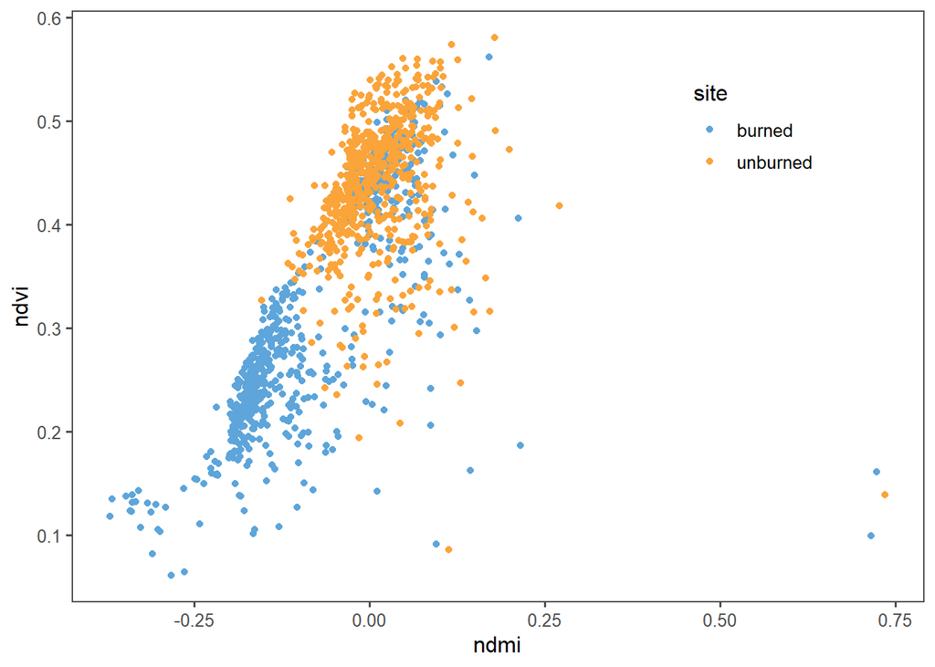

```r
q <- pivot_wider(full_long, names_from = "data", values_from = "value") %>%
  filter_if(is.numeric, all_vars(!is.na(.))) %>%
  mutate(month=month(DateTime),
       year=year(DateTime))
q_summer <- filter(q, month %in% c(6,7,8,9))

ggplot(q_summer,aes(x=ndmi,y=ndvi,color=site)) +
  geom_point() +
  theme_few() +
  scale_color_few() +
  theme(legend.position=c(0.8,0.8))
```

## Question 2

2. What is the correlation between average NDSI (normalized snow index) for January - April and average NDVI for June-August? In other words, does the previous year’s snow cover influence vegetation growth for the following summer?

### Answer 2

There may be a very slight but weak positive correlation between previous winter’s NDSI and current summer’s NDVI. NDVI typically ranges >0.38 for both unburned sites and burned sites pre-fire. The clustering of NDVI values <0.3 represents post-fire burned sites.

```r
q_annual_ndsi <- q %>%
  mutate(year=year(DateTime)) %>%
  mutate(month=month(DateTime)) %>%
  filter(month %in% c(1,2,3,4)) %>%
  group_by(site,year) %>%
  summarize(mean_NDSI=mean(ndsi))
q_annual_ndvi <- q %>%
  mutate(year=year(DateTime)) %>%
  mutate(month=month(DateTime)) %>%
  filter(month %in% c(6,7,8)) %>%
  group_by(site,year) %>%
  summarize(mean_NDVI=mean(ndvi))
q_snow2veg <- left_join(q_annual_ndsi, q_annual_ndvi)
```

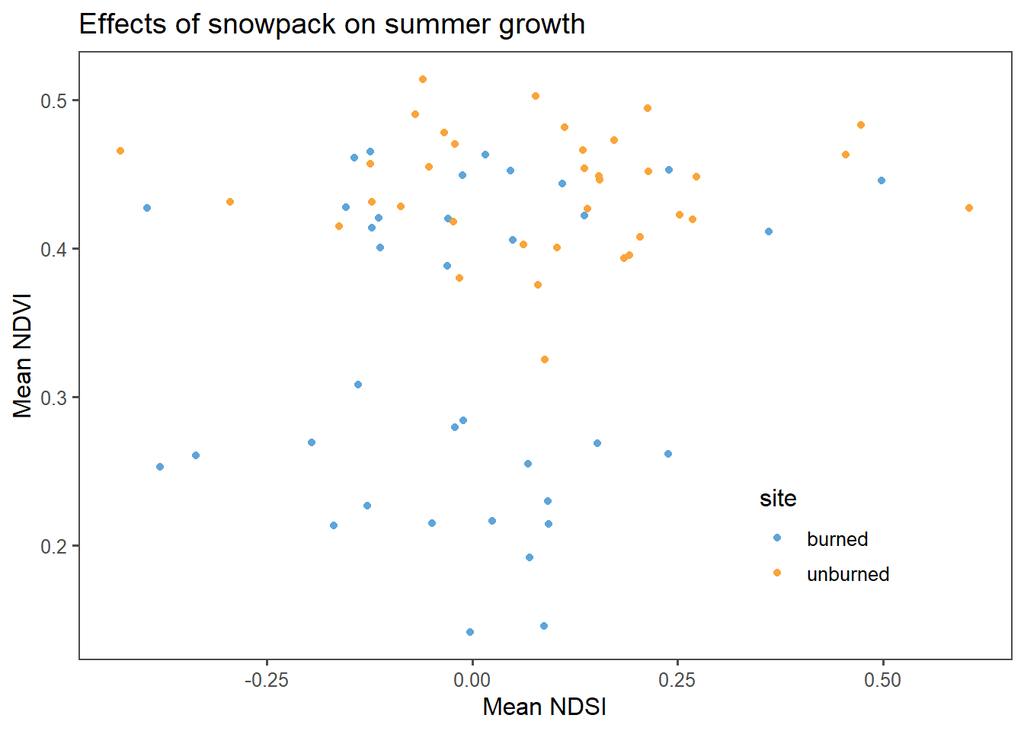

```r
ggplot(q_snow2veg,aes(x=mean_NDSI,y=mean_NDVI,color=site)) +
  geom_point() +
  theme_few() +
  scale_color_few() +
  xlab("Mean NDSI") + ylab("Mean NDVI") +
  ggtitle("Effects of snowpack on summer growth") +
  theme(legend.position=c(0.8,0.2))
```

## Q3

How is the snow effect from question 2 different between pre- and post-burn and burned and unburned?

### Answer 3

We can see a pretty drastic shift in post-fire NDVI between burned and unburned areas. We see similar mean NDSI values, but unburned NDVI is greater in all of these cases when compared to the NDVI in burned locations. This trend is not noticeable in the pre-fire values where the yet-to-be-burned locations have greater NDVI values consistent with the unburned locations.

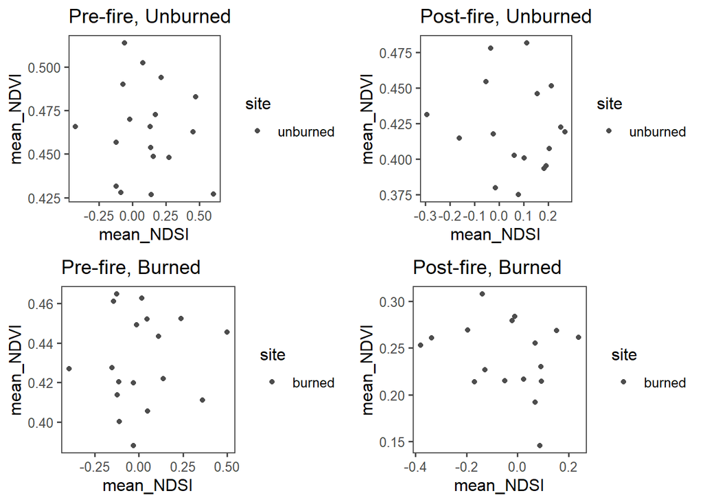

```r
q_snow2veg_burn <- q_snow2veg %>% filter(site=="burned")
q_snow2veg_unburn <- q_snow2veg %>% filter(site=="unburned")

#Breaking out burned/unburned entirely into different charts of pre- and post-fire
p1 <- ggplot(q_snow2veg_unburn %>% filter(year<2002),aes(x=mean_NDSI,y=mean_NDVI,color=site)) +
  geom_point() +
  theme_few() +
  scale_color_few() +
  ggtitle("Pre-fire, Unburned")

p2 <- ggplot(q_snow2veg_unburn %>% filter(year>2002),aes(x=mean_NDSI,y=mean_NDVI,color=site)) +
  geom_point() +
  theme_few() +
  scale_color_few() +
  ggtitle("Post-fire, Unburned")

p3 <- ggplot(q_snow2veg_burn %>% filter(year<2002),aes(x=mean_NDSI,y=mean_NDVI,color=site)) +
  geom_point() +
  theme_few() +
  scale_color_few() +
  ggtitle("Pre-fire, Burned")

p4 <- ggplot(q_snow2veg_burn %>% filter(year>2002),aes(x=mean_NDSI,y=mean_NDVI,color=site)) +
  geom_point() +
  theme_few() +
  scale_color_few() +
  ggtitle("Post-fire, Burned")
grid.arrange(p1, p2, p3, p4)
```

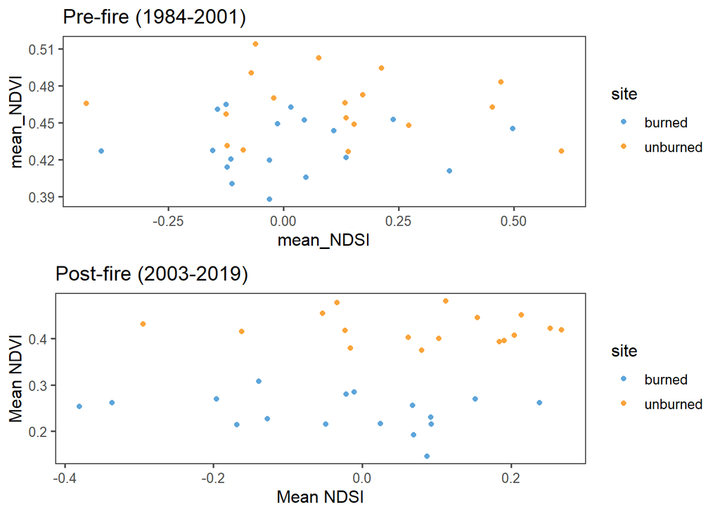

```r
#Combining burned/unburned but still separated by pre- and post-fire. More clean, better comparison
p1 <- ggplot(q_snow2veg %>% filter(year<2002),aes(x=mean_NDSI,y=mean_NDVI,color=site)) +
  geom_point() +
  theme_few() +
  scale_color_few() +
  ggtitle("Pre-fire (1984-2001)")

p2 <- ggplot(q_snow2veg %>% filter(year>2002),aes(x=mean_NDSI,y=mean_NDVI,color=site)) +
  geom_point() +
  theme_few() +
  scale_color_few() +
  xlab("Mean NDSI") + ylab("Mean NDVI") +
  ggtitle("Post-fire (2003-2019)")
grid.arrange(p1,p2)
```

## Question 4

What month is the greenest month on average?

### Answer 4

The greenest month on average for all sites and years is August with an average NDVI of 0.387, while September has an average NDVI of 0.383. When we analyze just unburned locations across the time period, September is the greenest month with an average NDVI of 0.459, though June-October have average NDVI > 0.4.

```r
#All sites across time
q_monthly_ndvi <- q %>%
  mutate(month=month(DateTime)) %>%
  group_by(month) %>%
  summarize(mean_NDVI=mean(ndvi))

#Broken out by site
q_monthly_ndvi2 <- q %>%
  mutate(month=month(DateTime)) %>%
  group_by(month, site) %>%
  summarize(mean_NDVI=mean(ndvi))
```

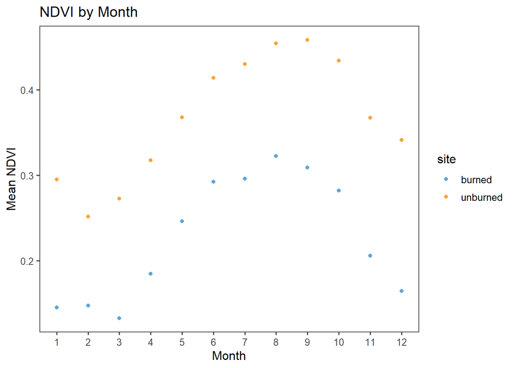

```r
#Combining burned/unburned but still separated by pre- and post-fire. More clean, better comparison
ggplot(q_monthly_ndvi2,aes(x=month,y=mean_NDVI,color=site)) +
  geom_point() +
  theme_few() +
  scale_color_few() +
  scale_x_continuous(breaks=seq(0,12,by=1)) +
  xlab("Month") + ylab("Mean NDVI") +
  ggtitle("NDVI by Month")
```

## Question 5

What month is the snowiest on average?

### Answer 5

The snowiest month on average for all sites and years is January with an average NDSI of 0.210, while February has an average NDSI of 0.198. When we analyze just unburned locations across the time period, February is the snowiest month with an average NDSI of 0.273, and December-February is consistently snowier in unburned sites than burned sites.

```r
#All sites across time
q_monthly_ndsi <- q %>%
  mutate(month=month(DateTime)) %>%
  group_by(month) %>%
  summarize(mean_NDSI=mean(ndsi))

#Broken out by site
q_monthly_ndsi2 <- q %>%
  mutate(month=month(DateTime)) %>%
  group_by(month, site) %>%
  summarize(mean_NDSI=mean(ndsi))
```

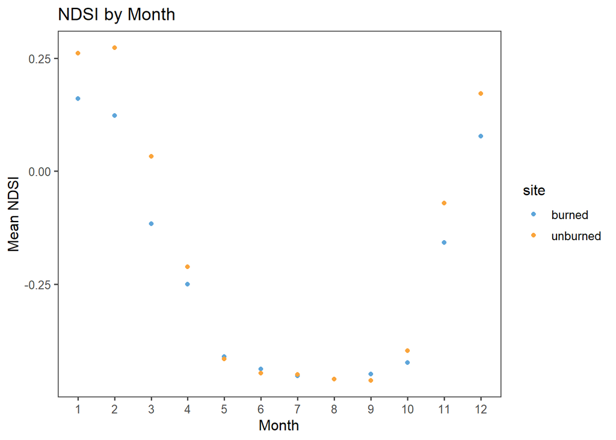

```r
#Combining burned/unburned but still separated by pre- and post-fire. More clean, better comparison
ggplot(q_monthly_ndsi2,aes(x=month,y=mean_NDSI,color=site)) +
  geom_point() +
  theme_few() +
  scale_color_few() +
  scale_x_continuous(breaks=seq(0,12,by=1)) +
  xlab("Month") +
  ylab("Mean NDSI") +
  ggtitle("NDSI by Month")
```

## Bonus Question

Redo all problems with `spread` and `gather` using modern tidyverse syntax.

### Bonus Answer

`spread` -> `pivot_wider`; `gather` -> `pivot_longer` Completed using `pivot_wider` and `pivot_longer` within my code. I also updated full_long and full_long2 using `pivot_longer` but named it full_long_a and full_long2_a.

## Bonus Question

Use Climate Engine to pull the same data for the assignment, but updated with 2020/2021 data.

### Bonus Answer

Ran out of time and used function `had_to_call_it_quits`.